# AQI Category Agreement Analysis Tutorial

Elizabeth Good

July 16, 2025

# Set Up

This makes sure the necessary packages are installed and loaded and that the functions are called in from their source script *‘functions_for_AQI_barplots.R’*. Note that this Rmd uses the `here` package to work with paths in this repository. The `here` package constructs paths relative to the project root.

```r
# Load necessary packages
if(!require("MazamaCoreUtils"))
  install.packages("MazamaCoreUtils")
if(!require("dplyr"))
  install.packages("dplyr")
if(!require("AirMonitor"))
  install.packages("AirMonitor")
if(!require("AirMonitorPlots"))
  devtools::install_github('mazamascience/AirMonitorPlots', build_vignettes=TRUE)
if(!require("tidyverse"))
  install.packages("tidyverse")
if(!require("AirSensor2"))
  devtools::install_github('mazamascience/AirSensor2')
if(!require("ggpubr"))
  install.packages("ggpubr")
if(!require("here"))
  install.packages("here")

library(MazamaCoreUtils)
library(dplyr)
library(AirMonitor)
library(AirMonitorPlots)
library(tidyverse)
library(AirSensor2)
library(ggpubr)
library(here)

# Load utility functions from 'functions_for_AQI_barplots.R'
source(here("R", "functions_for_AQI_barplots.R"))  # input the file path to 'functions_for_AQI_barplots.R'
```

# Sensor Data Prep

Next, load in your sensor data and use it to create the *mts_monitor* object that will be used for comparison against the AirNow reference monitors. This Rmd uses some example sensor data, which can also be used to help understand the required data format for your own sensor data. Ensure your data is in **UTC** time; the example data has already been converted to UTC time stamps.

```r
# Load in sensor data
meta_df <- read_csv(here("data", "clarity_meta.csv")) # input file path to meta data (recommend using 'read_csv' rather than 'read.csv')

data_df <- read_csv(here("data", "clarity_data.csv")) # input file path to time series data (recommend using 'read_csv' rather than 'read.csv')

# Create mts_monitor object
sensor <- list(meta = meta_df,
               data = data_df)

sensor <- structure(sensor,
                    class = c("mts_monitor", "mts", class(sensor)))
```

## Important Requirements for Sensor Data

The sensor data must consist of two files (.csv or .xlsx format), one of meta data and one of time series data that will be combined into a *mts_monitor* object for analysis. To read more about the *mts_monitor* data format, see https://mazamascience.github.io/MazamaTimeSeries/ .

### Sensor Meta Data

The meta data file must have each row as a unique device and columns of device meta data.

- Required columns must include (written and titled **exactly** as below):
  - *deviceDeploymentID*
  - *deviceID*
  - *locationID*
  - *locationName*
  - *longitude*
  - *latitude*
  - *elevation*
  - *countryCode*
  - *stateCode*
  - *countyName*
  - *timezone*
- All columns are of class character except *longitude*, *latutide*, and *elevation* which are of class numeric.
- The *elevation* and *timezone* columns must exist for functions to run, but aren’t required to be populated (can be left blank).
- *deviceDeploymentID*, *deviceID*, and *locationID* are character identifiers for the sensors. *locationID* is typically generated from the latitude/longitude data, *deviceID* is an identification for the sensor, and *deviceDeploymentID* is a combination of the *locationID* and *deviceID*.
- Any additional meta data columns beyond those listed above can be included.

### Sensor Time Series Data

The time series data file must have each row as an hourly **UTC** timestamp (with date and time) and columns of the measured parameter for each device, plus the first column for the timestamps.

- The column titles must be:
  - *datetime*
  - the *deviceDeploymentID* used in the meta data

**IMPORTANT**: The order of the *deviceDeploymentID* down the rows of the meta data must match the order of the *deviceDeploymentID* across the columns of the time series data after the datetime column.

- For example, if sensor123abc is the first row in the meta data, then sensor123abc must also be the second column in the time series data after the datetime column. If sensor456def is the second row in the meta data, then sensor456def must also be the third column in the time series data after the datetime column and the first sensor.

# Reference AirNow Data

Data from AirNow can easily be loaded in for specific windows of time using the `monitor_load` function from the `AirMonitor` package, and loads in with **UTC** time stamps. Choose a start and end date to match your sensor data; any missing data within the start and end dates are irrelevant. Note that this could take a few minutes to load depending on how much data you’re trying to load.

```r
# Load in AirNow data
airnow <- monitor_load(
  startdate = 20230530,            # input start and end date to match sensor data
  enddate =   20231003             # format example: startdate = 20210601
)
```

Data might need to be trimmed slightly for timestamps to match. In this example, the sensor data is missing the first two hours at the beginning of the time frame of interest, so the AirNow data will be trimmed slightly to match.

```r
# trim AirNow data to match sensor data time stamps
airnow$data <- airnow$data[-c(1:2),]
```

# Find Adjacent Pairs

Now that data is loaded, you can use the `findAdjacentPairs` function to find sensors that are within a specifid radius of nearby AirNow monitors. The proposed radius for analysis is 1000 meters, but this can be easily adjusted in the `findAdjacentPairs` function to test any radius in meters. This function adds two columns to the sensor meta data: the *airnow_closestDistance* and the *airnow_id* to identify the nearest AirNow monitors to the sensors within the specified radius. The following warning may appear when this function is used and can be ignored: “number of items to replace is not a multiple of replacement length.” The AirNow data is then filtered to retain the monitors nearby the sensors, and the PM2.5 NowCast algorithm is applied to be most representative of how data is displayed on the Fire and Smoke map. To read more about the function and the NowCast algorithm, see https://mazamascience.github.io/AirMonitor/articles/NowCast.html.

```r
# returns mts_monitor object of sensors within specified radius of reference monitors
sensor_adjacent <- findAdjacentPairs(sensor = sensor,
                                     airnow = airnow,
                                     1000)    # specify the radius in meters

# call out the ids of the adjacent pairs
airnow_ids <- unique(sensor_adjacent$meta$airnow_id)
sensor_ids <- unique(sensor_adjacent$meta$deviceDeploymentID)

# filter the airnow data set for adjacent pairs
airnow_adjacent <-
  airnow %>%
  monitor_select(airnow_ids)

# apply the NowCast algorithm
sensor_adjacent <-
  sensor_adjacent %>%
  monitor_nowcast(includeShortTerm = TRUE)

airnow_adjacent <-
  airnow_adjacent %>%
  monitor_nowcast(includeShortTerm = TRUE)
```

# Unlisted AQI Category Data Frame

The `create_AQI_unlisted` function returns a data frame named “AQI_unlisted” with two columns, *airnow* and *sensor*. This is the PM2.5 NowCast AQI category for each hour where the sensor and AirNow monitor pairs both have data. The AQI categories are represented as numbers, as described in the table below.

| AQI Category | Number Assignment |
| --- | --- |
| Good | 1 |
| Moderate | 2 |
| Unhealthy for Sensitive Groups | 3 |
| Unhealthy | 4 |
| Very Unhealthy | 5 |
| Hazardous | 6 |

```r
AQI_unlisted <- create_AQI_unlisted(sensor_adjacent = sensor_adjacent,
                                    airnow_adjacent = airnow_adjacent)
```

# Overall AQI Category Agreement Bar Plot

The `create_combined_barplot` function accepts the `AQI_unlisted` data frame and returns a bar plot comparing AQI categroy agreement between the sensors and AirNow monitors across all AQI categories combined. You can specify horizontal lines where thresholds for agreement can be visualized. Thresholds can be shown for plus/minus one AQI category and plus/minus two or more AQI categories. Currently, the proposed thresholds for plus/minus one AQI category is no more than **5%** of the time and plus/minus two or more AQI categories no more than **1%** of the time.

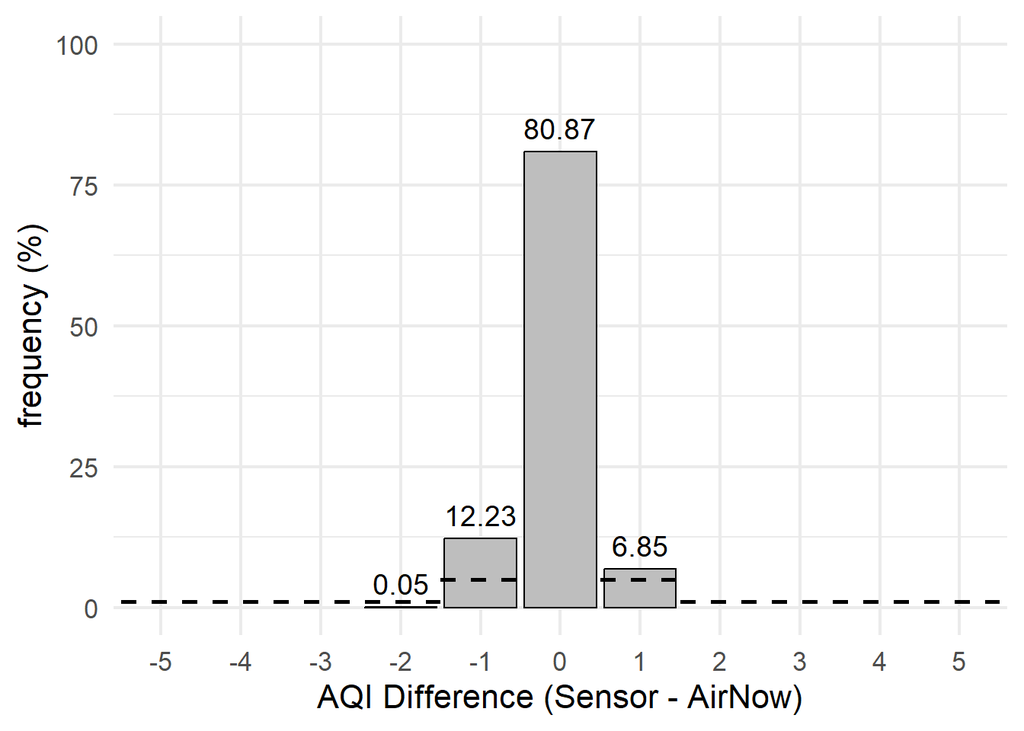

```r
create_combined_barplot(AQI_unlisted = AQI_unlisted,
                        threshold_1 = 5, # input the threshold for plus/minus one AQI category
                        threshold_2 = 1) # input the threshold for plus/minus two or more AQI categories
```

# AQI Category Agreement Bar Plot Grid

There are a series of function for making AQI category agreement bar plot grids depending on the highest AQI category your reference monitor data reaches. They are all named beginning with `create_categories_barplot_[AQI Category]`. These functions create a bar plot grid showing AQI category agreement by sensors compared to AirNow monitors for each AQI category reported by the reference monitors. Choose the function based on the highest AQI category that’s reported by your reference monitor data. For example, if you reference monitor data reaches the Very Unhealhty category (represented by the number 5 in the `AQI_unlisted` data frame) you would use the `create_categories_barplot_veryunhealthy` function. As above, thresholds can be shown for plus/minus one AQI category and plus/minus two or more AQI categories. Currently, the proposed thresholds for plus/minus one AQI category is no more than **30%** of the time and plus/minus two or more AQI categories no more than **1%** of the time within each AQI category reported by the reference monitors.

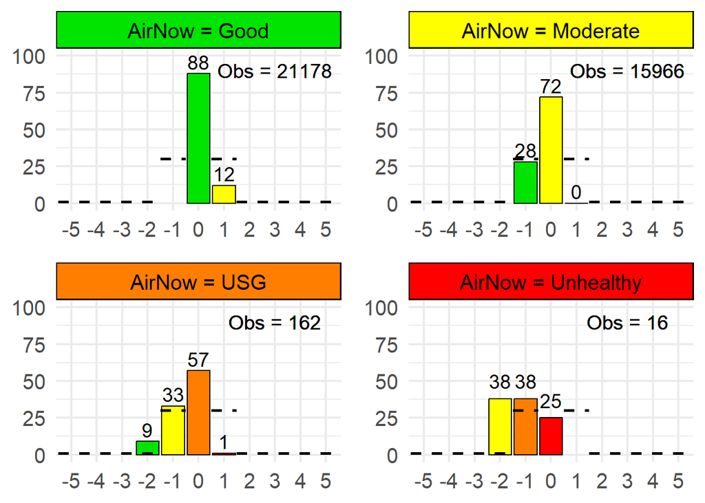

```r
# with this example data, the max AQI category from the reference monitors was Unhealthy (4)
create_categories_barplot_unhealthy(AQI_unlisted = AQI_unlisted,
                                    threshold_1 = 30, # input the threshold for plus/minus one AQI category
                                    threshold_2 = 1)  # input the threshold for plus/minus two or more AQI categories
```